# NYC Jobs

Roland Gjopalaj

2023-01-29

## Overview

[This dataset contains current job postings available on the City of New York’s official jobs site](http://www.nyc.gov/html/careers/html/search/search.shtml)

Internal postings available to city employees and external postings available to the general public are included.

## Libraries to import

```r
library(tidyr)
library(dplyr)
library(readr)
library(lubridate)
library(ggplot2)
```

## Dataset to import

The dataset we are going to use to do our studyng.

```r
## Import the dataset

jobs = read_csv("JOBS_nyc.csv")
jobs
```

```
## # A tibble: 5,538 × 28
##    `Job ID` Agency Posti…¹ # Of …² Busin…³ Civil…⁴ Title…⁵ Title…⁶ Level Job C…⁷
##       <dbl> <chr>  <chr>     <dbl> <chr>   <chr>   <chr>   <chr>   <chr> <chr>
##  1   465164 DEPAR… Extern…       2 Legal … LEGAL … Compet… 30081   00    Consti…
##  2   546753 DEPT … Intern…       1 Field … TELECO… Compet… 20247   02    Techno…
##  3   546753 DEPT … Intern…       1 Field … TELECO… Compet… 20247   02    Techno…
##  4   563090 DEPT … Extern…       1 Inspec… PUBLIC… Compet… 31215   01    Health…
##  5   564955 DEPT … Extern…       1 Mechan… MECHAN… Compet… 20415   03    Engine…
##  6   569503 DEPAR… Intern…       2 Assist… AGENCY… Non-Co… 30087   02    Legal …
##  7   567011 HUMAN… Intern…       1 Associ… ASSOCI… Compet… 55038   01    Consti…
##  8   546631 HRA/D… Intern…       1 PROJEC… COMPUT… Compet… 13632   03    Techno…
##  9   531571 POLIC… Intern…       1 Senior… SENIOR… Compet… 10147   00    Admini…
## 10   553393 DEPT … Intern…      10 Outrea… SENIOR… Non-Co… 56101   00    Consti…
## # … with 5,528 more rows, 18 more variables:
## #   `Full-Time/Part-Time indicator` <chr>, `Career Level` <chr>, Salary <chr>,
## #   `Work Location` <chr>, `Division/Work Unit` <chr>, `Job Description` <chr>,
## #   `Minimum Qual Requirements` <chr>, `Preferred Skills` <chr>,
## #   `Additional Information` <chr>, `To Apply` <chr>, `Hours/Shift` <chr>,
## #   `Work Location 1` <chr>, `Recruitment Contact` <lgl>,
## #   `Residency Requirement` <chr>, `Posting Date` <chr>, `Post Until` <chr>, …
```

## Cleanin the dataset

If you take a look at the data you will notice that some of the rows are duplicated and that in not efficient so we are going to remove all of theme.

```r
## remove the duplicated lines
jobs = jobs[!duplicated(jobs), ]
jobs
```

```
## # A tibble: 5,443 × 28
##    `Job ID` Agency Posti…¹ # Of …² Busin…³ Civil…⁴ Title…⁵ Title…⁶ Level Job C…⁷
##       <dbl> <chr>  <chr>     <dbl> <chr>   <chr>   <chr>   <chr>   <chr> <chr>
##  1   465164 DEPAR… Extern…       2 Legal … LEGAL … Compet… 30081   00    Consti…
##  2   546753 DEPT … Intern…       1 Field … TELECO… Compet… 20247   02    Techno…
##  3   563090 DEPT … Extern…       1 Inspec… PUBLIC… Compet… 31215   01    Health…
##  4   564955 DEPT … Extern…       1 Mechan… MECHAN… Compet… 20415   03    Engine…
##  5   569503 DEPAR… Intern…       2 Assist… AGENCY… Non-Co… 30087   02    Legal …
##  6   567011 HUMAN… Intern…       1 Associ… ASSOCI… Compet… 55038   01    Consti…
##  7   546631 HRA/D… Intern…       1 PROJEC… COMPUT… Compet… 13632   03    Techno…
##  8   531571 POLIC… Intern…       1 Senior… SENIOR… Compet… 10147   00    Admini…
##  9   553393 DEPT … Intern…      10 Outrea… SENIOR… Non-Co… 56101   00    Consti…
## 10   553899 HRA/D… Intern…       1 SECTIO… PRINCI… Compet… 10124   03    Admini…
## # … with 5,433 more rows, 18 more variables:
## #   `Full-Time/Part-Time indicator` <chr>, `Career Level` <chr>, Salary <chr>,
## #   `Work Location` <chr>, `Division/Work Unit` <chr>, `Job Description` <chr>,
## #   `Minimum Qual Requirements` <chr>, `Preferred Skills` <chr>,
## #   `Additional Information` <chr>, `To Apply` <chr>, `Hours/Shift` <chr>,
## #   `Work Location 1` <chr>, `Recruitment Contact` <lgl>,
## #   `Residency Requirement` <chr>, `Posting Date` <chr>, `Post Until` <chr>, …
```

After that we need to remove the unnecessary data and to keep only the data we want to use.

To facilitate a little bit our work we can change the names of the columns so we don’t need to use characters as “`”.

```r
## Select the necessary data and rename the columns (practical names)

jobs = jobs %>%
  select(`Job ID`, `Agency`, `Posting Type`, `# Of Positions`, `Title Classification`, `Job Category`, `Full-Time/Part-Time indicator`, `Career Level`, `Salary`, `Work Location`, `Division/Work Unit`, `Posting Date`, `Posting Updated`) %>%
  rename(Id=`Job ID`, Posting_Type=`Posting Type`, Nr_of_Positions=`# Of Positions`, Classification=`Title Classification`, Job_Category=`Job Category`, FullPart_Time=`Full-Time/Part-Time indicator`, Career_Level=`Career Level`, Work_Location=`Work Location`, Work_Unit=`Division/Work Unit`, Posting_Date=`Posting Date`, Posting_Updated=`Posting Updated`)

 jobs
```

```
## # A tibble: 5,443 × 13
##        Id Agency  Posti…¹ Nr_of…² Class…³ Job_C…⁴ FullP…⁵ Caree…⁶ Salary Work_…⁷
##     <dbl> <chr>   <chr>     <dbl> <chr>   <chr>   <chr>   <chr>   <chr>  <chr>
##  1 465164 DEPART… Extern…       2 Compet… Consti… <NA>    Experi… 47418… 75-20 …
##  2 546753 DEPT O… Intern…       1 Compet… Techno… F       Experi… 75000… Randal…
##  3 563090 DEPT O… Extern…       1 Compet… Health… F       Experi… 45722… 22 Cor…
##  4 564955 DEPT O… Extern…       1 Compet… Engine… F       Experi… 90114… 3701 J…
##  5 569503 DEPART… Intern…       2 Non-Co… Legal … <NA>    Experi… 71423… 22 Rea…
##  6 567011 HUMAN … Intern…       1 Compet… Consti… F       Experi… 58449… 22 Rea…
##  7 546631 HRA/DE… Intern…       1 Compet… Techno… F       Experi… 92194… 15 Met…
##  8 531571 POLICE… Intern…       1 Compet… Admini… F       Experi… 43929… 1 Poli…
##  9 553393 DEPT O… Intern…      10 Non-Co… Consti… F       Entry-… 15.45… 2 Lafa…
## 10 553899 HRA/DE… Intern…       1 Compet… Admini… F       Experi… 58695… 470 Va…
## # … with 5,433 more rows, 3 more variables: Work_Unit <chr>,
## #   Posting_Date <chr>, Posting_Updated <chr>, and abbreviated variable names
## #   ¹Posting_Type, ²Nr_of_Positions, ³Classification, ⁴Job_Category,
## #   ⁵FullPart_Time, ⁶Career_Level, ⁷Work_Location
```

In the dataset we have a column that doesn’t contain atomic data so the best choice is to separate it into atomic data so we can use the data properly.

```r
## Fix the salary problem (not atomic data)
## separating salary interval in  different columns

jobs = jobs %>%
  separate(Salary, into = c("Salary_From", "Salary_To", "Salary_Frequency"),
         sep = "-", convert = TRUE)

jobs
```

```
## # A tibble: 5,443 × 15
##        Id Agency Posti…¹ Nr_of…² Class…³ Job_C…⁴ FullP…⁵ Caree…⁶ Salar…⁷ Salar…⁸
##     <dbl> <chr>  <chr>     <dbl> <chr>   <chr>   <chr>   <chr>     <dbl>   <dbl>
##  1 465164 DEPAR… Extern…       2 Compet… Consti… <NA>    Experi… 47418    5.45e4
##  2 546753 DEPT … Intern…       1 Compet… Techno… F       Experi… 75000    7.5 e4
##  3 563090 DEPT … Extern…       1 Compet… Health… F       Experi… 45722    4.57e4
##  4 564955 DEPT … Extern…       1 Compet… Engine… F       Experi… 90114    1.22e5
##  5 569503 DEPAR… Intern…       2 Non-Co… Legal … <NA>    Experi… 71423    8.21e4
##  6 567011 HUMAN… Intern…       1 Compet… Consti… F       Experi… 58449    6.72e4
##  7 546631 HRA/D… Intern…       1 Compet… Techno… F       Experi… 92194    1.06e5
##  8 531571 POLIC… Intern…       1 Compet… Admini… F       Experi… 43929    5.71e4
##  9 553393 DEPT … Intern…      10 Non-Co… Consti… F       Entry-…    15.4  1.76e1
## 10 553899 HRA/D… Intern…       1 Compet… Admini… F       Experi… 58695    6.75e4
## # … with 5,433 more rows, 5 more variables: Salary_Frequency <chr>,
## #   Work_Location <chr>, Work_Unit <chr>, Posting_Date <chr>,
## #   Posting_Updated <chr>, and abbreviated variable names ¹Posting_Type,
## #   ²Nr_of_Positions, ³Classification, ⁴Job_Category, ⁵FullPart_Time,
## #   ⁶Career_Level, ⁷Salary_From, ⁸Salary_To
```

```r
## create a salary index (per hour)

jobs = jobs %>%
  mutate(Salary_Index =
           ifelse(Salary_Frequency=="Hourly",
                 (Salary_From+Salary_To)/2,
                 ifelse(FullPart_Time=="P",
                       ## if the work is  part-time
                       ifelse(Salary_Frequency=="Annual",
                             (Salary_From+Salary_To)/(17*260),
                             (Salary_From+Salary_To)/(17)
                       ),
                       ## if the work is  full-time
                       ifelse(Salary_Frequency=="Annual",
                             (Salary_From+Salary_To)/(37*260),
                             (Salary_From+Salary_To)/(37)
                       )
                 )
          )
      )

jobs
```

```
## # A tibble: 5,443 × 16
##        Id Agency Posti…¹ Nr_of…² Class…³ Job_C…⁴ FullP…⁵ Caree…⁶ Salar…⁷ Salar…⁸
##     <dbl> <chr>  <chr>     <dbl> <chr>   <chr>   <chr>   <chr>     <dbl>   <dbl>
##  1 465164 DEPAR… Extern…       2 Compet… Consti… <NA>    Experi… 47418    5.45e4
##  2 546753 DEPT … Intern…       1 Compet… Techno… F       Experi… 75000    7.5 e4
##  3 563090 DEPT … Extern…       1 Compet… Health… F       Experi… 45722    4.57e4
##  4 564955 DEPT … Extern…       1 Compet… Engine… F       Experi… 90114    1.22e5
##  5 569503 DEPAR… Intern…       2 Non-Co… Legal … <NA>    Experi… 71423    8.21e4
##  6 567011 HUMAN… Intern…       1 Compet… Consti… F       Experi… 58449    6.72e4
##  7 546631 HRA/D… Intern…       1 Compet… Techno… F       Experi… 92194    1.06e5
##  8 531571 POLIC… Intern…       1 Compet… Admini… F       Experi… 43929    5.71e4
##  9 553393 DEPT … Intern…      10 Non-Co… Consti… F       Entry-…    15.4  1.76e1
## 10 553899 HRA/D… Intern…       1 Compet… Admini… F       Experi… 58695    6.75e4
## # … with 5,433 more rows, 6 more variables: Salary_Frequency <chr>,
## #   Work_Location <chr>, Work_Unit <chr>, Posting_Date <chr>,
## #   Posting_Updated <chr>, Salary_Index <dbl>, and abbreviated variable names
## #   ¹Posting_Type, ²Nr_of_Positions, ³Classification, ⁴Job_Category,
## #   ⁵FullPart_Time, ⁶Career_Level, ⁷Salary_From, ⁸Salary_To
```

After that we need to add a new column that will be called ACR that stands for acronym and will be a abbreviation of the agency name (because during the presentation and the visualization the abbreviation will look batter and it wont overlap).

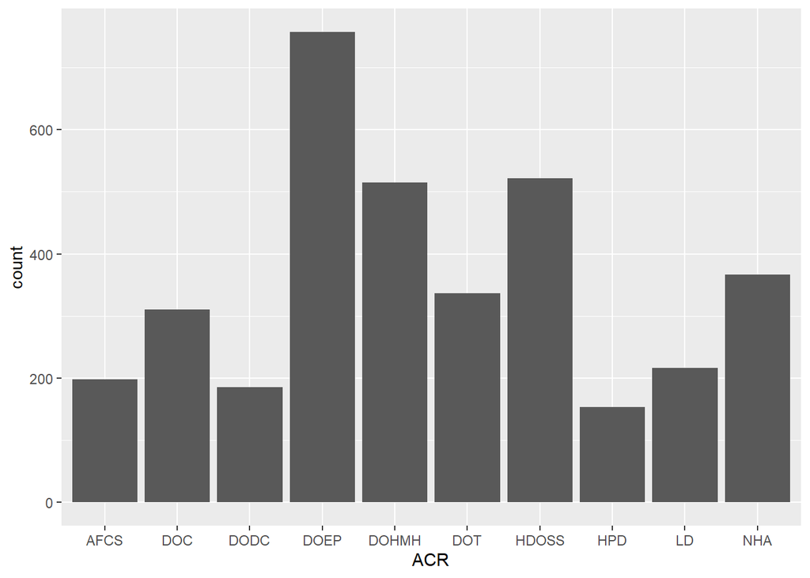

```r
##I used this command to ad the ACR for every agency to be more visible on the chart
##jobs = mutate(jobs, ACR = ifelse(Agency=="AGENCY NAME", "ACR", ACR))

##Just execute this command to go on
jobs = read.csv("JOBS_ncyV2.csv")##The dataset after adding the acronym column(ACR)

##select the agencies that have the most number of postings
agencyMore=count(jobs, ACR) %>%
  arrange(-n) %>%
  top_n(10) %>%
  pull(ACR) %>%
  unlist()

agencyMore = jobs %>% filter(ACR %in% agencyMore)

##visualize it
ggplot(data = agencyMore) +
  geom_bar(mapping = aes(x = ACR))
```

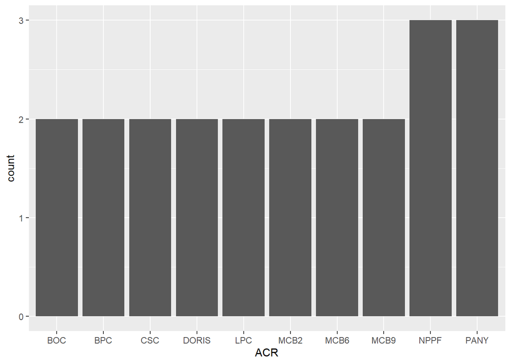

```r
#####################################################
##select the agencies that have the lower number of postings
agencyLess=count(jobs, ACR) %>%
  arrange(n)  %>%
  pull(ACR) %>%
  unlist()

##another way to select the first 10
agencyLess=agencyLess[0:10]

agencyLess = jobs %>% filter(ACR %in% agencyLess)

ggplot(data = agencyLess) +
  geom_bar(mapping = aes(x = ACR))
```

Here we fix the column <*Posting_Date*> by converting it from string to Data

```r
jobs = read.csv("JOBS_ncyV2.csv")

##fix the date(convert it from string to date)
jobs = jobs %>%
  separate(Posting_Date, c("month", "day", "year"), sep = "/") %>%
  mutate(Posting_Date = make_date(year, month, day)) %>%
  select(Id:Work_Unit, Posting_Date, Posting_Updated:ACR)
jobs = jobs %>%
  separate(Posting_Updated, c("month", "day", "year"), sep = "/") %>%
  mutate(Posting_Updated = make_date(year, month, day)) %>%
  select(Id:Posting_Date, Posting_Updated, Salary_Index, ACR)
```

Here we do the same thing as above. Change some values so are more visible and dont overlap.

Here we show the salaries in base of the career level and also the difficulty and the size that shows the number of open positions for that job Than we filter the time to have a closer look at the information given.

A fun fact of this plot is that we can notice that for some reason the “experienced but not managers can gain more than managers at some different jobs before 2023. And in 2023 some entry-level jobs pay more than the others.

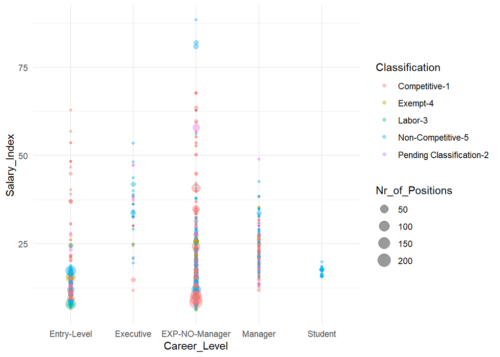

```r
##change some values for better visibility
jobs["Career_Level"][jobs["Career_Level"] == "Experienced (non-manager)"] = "EXP-NO-Manager"


## show the salaries in base of the career level
## and with the help of the colors we can see the level of the difficulty
## The size indeed shows the number of open positions for that job
## we can also filter the time (from a given year to the day of 17/01/2013)
show = function(posting_type, myDateFrom) {
  jobs[!is.na(jobs$Career_Level), ] %>% ##remove the NA elements
    filter(Salary_From>0, Posting_Type==posting_type, Posting_Date > myDateFrom) %>%
    ggplot(aes(Career_Level, Salary_Index, colour = Classification, size=Nr_of_Positions)) +
    geom_point(alpha = 0.4, na.rm = TRUE) +
    theme_minimal()
}



show("External", as.Date(paste(2015,"-", 1, "-",1, sep = "")))
```

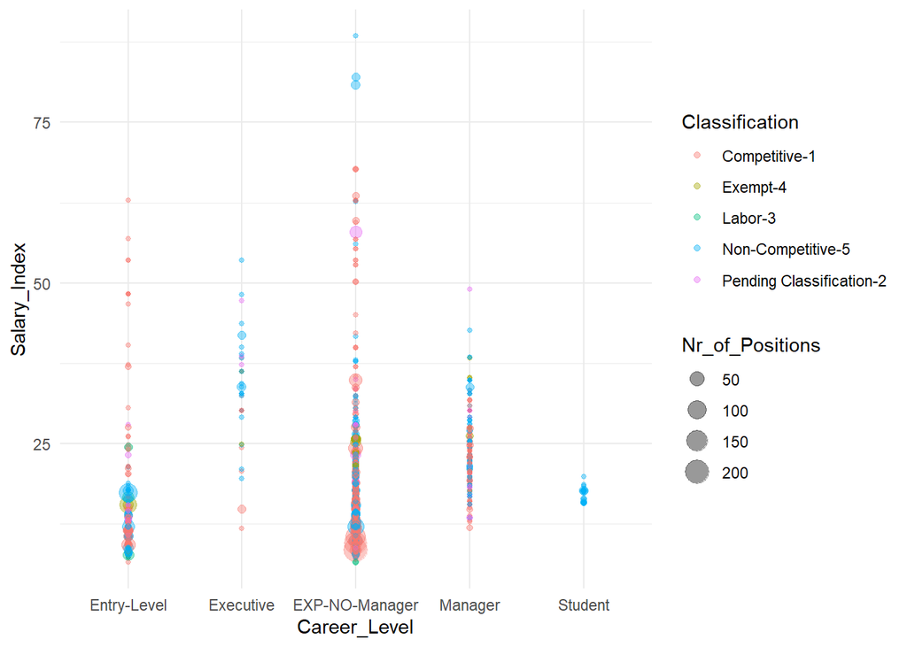

```r
show("External", as.Date(paste(2022,"-", 1, "-",1, sep = "")))
```

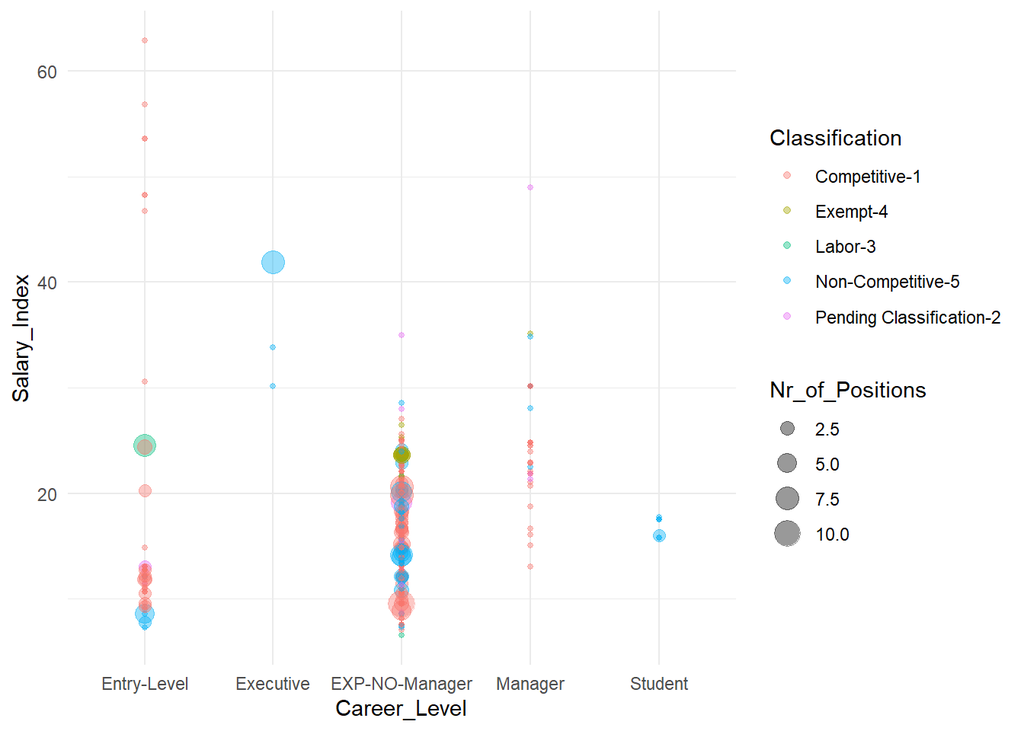

```r
show("Internal", as.Date(paste(2023,"-", 1, "-",1, sep = "")))
```

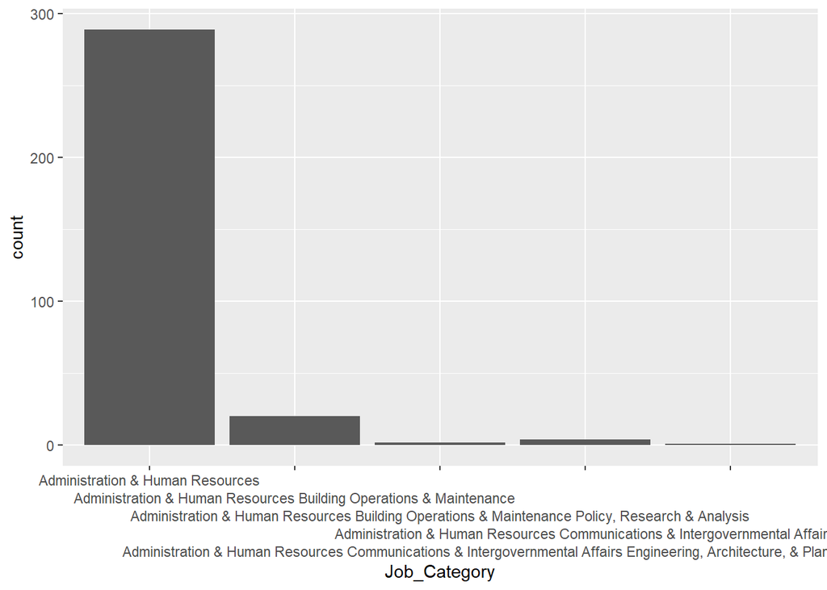

```r
## Top 10 most frequent Job_category
topCategory = jobs %>%
  count(Job_Category) %>%
  pull(Job_Category) %>%
  unlist()
topCategory = topCategory[0:5]

ggplot(data = filter(jobs, Job_Category %in% topCategory)) +
  geom_bar(mapping = aes(x = Job_Category))+
  scale_x_discrete(guide = guide_axis(n.dodge=5))
```

This plot shows posts during the years based on the number of opened positions, divided by the classification group, and with some salary details.(salary “per hour”)

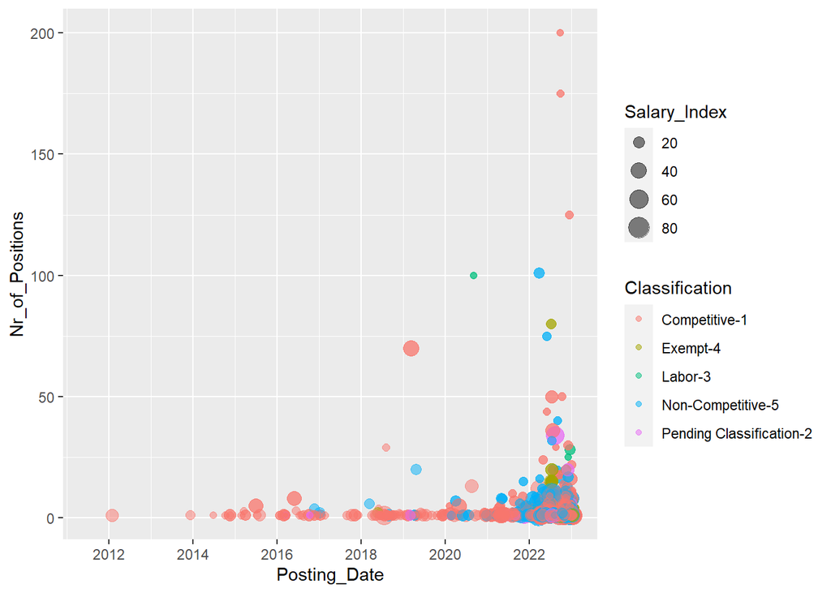

```r
## posts during the years based on the number of opened positions, divided by the classification group, and with some salary details.
jobs %>%
  ggplot(aes(Posting_Date, Nr_of_Positions, colour = Classification, size= Salary_Index))+
  geom_point(alpha = 0.5, na.rm = TRUE)+
   scale_x_date(date_labels = "%Y")
```

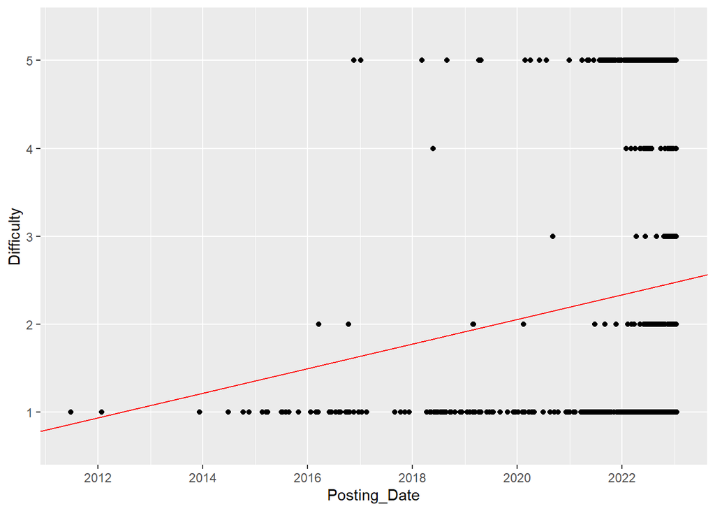

```r
##create a column difficulty(numeric) that will be the numeric interpretation of classification

## First we remove the "-" symbol to avoid problems with separating
jobs["Classification"][jobs["Classification"] == "Non-Competitive-5"] = "NonCompetitive-5"

##create a model of how the difficulty of a job goes based on the salary


jobsDiff=jobs %>%
  separate(Classification, c("Classification","Difficulty"), sep = "-")

mod = lm( Difficulty ~ Posting_Date, data = jobsDiff)
##summary(mod)


jobsDiff %>%
  ggplot(aes(Posting_Date,Difficulty))+
  geom_point(na.rm = TRUE)+
  geom_abline(intercept = mod$coefficients[1],
              slope = mod$coefficients[2],
              color = "red")
```